### Author: Terry Migwi

### Date: 19th September 2020

### Week 14 IP: Assosiation Analysis

# 1.Defining the Question

## Specifying the Data Analytic Question

Create association rules that will allow for identification of relationships between items given a dataset that comprises groups of items from Carrefour supermarkets.

## Defining the Metrics for success

This study will be considered successful if:

- relationships between the items are identified and are clearly explained
- insights are drawn from the relationships and recommendations are given

## Understanding the context

Identifying relationships between items is an important aspect in today’s retail environments as there’s a growing trend in customers expecting the sellers to tell what they might want to buy. If sellers can tell the customers what they might want to buy – it not only improves their sales, but also the customer experience and ultimately life time value.

**Why is this study relevant?*

As a Data Scientist of Carrefour Kenya, this study will help inform the marketing team on which items should be placed together in the stores and in what aisles. This will assist the team to come up with the most relevant marketing strategies that will result in the highest no. of sales. At large, this study will help come up with a more detailed explanation of how to make business decisions in retail environments.

```r
#loading necessary libraries
library(arulesViz)
library(arules)
```

## 2.Loading the Data

```r
#loading the data as transactions using the read.transactions function

#library(arules)
sales.data <- read.transactions("C:\\Users\\USER\\Downloads\\IP's datasets\\Module 3 Core - R Programming\\Supermarket_Sales_Dataset II.csv", sep = ",")
sales.data
```

```
## transactions in sparse format with
##  7501 transactions (rows) and
##  119 items (columns)
```

We have 7501 rows of transactions and 119 columns

## 3.Checking the Data

```r
#verifying the object's class
class(sales.data)
```

```
## [1] "transactions"
## attr(,"package")
## [1] "arules"
```

The class verifies that the data is inform of transactions

```r
#previewing our first five transactions
inspect(sales.data[1:5])
```

```
##     items
## [1] {almonds,
##      antioxydant juice,
##      avocado,
##      cottage cheese,
##      energy drink,
##      frozen smoothie,
##      green grapes,
##      green tea,
##      honey,
##      low fat yogurt,
##      mineral water,
##      olive oil,
##      salad,
##      salmon,
##      shrimp,
##      spinach,
##      tomato juice,
##      vegetables mix,
##      whole weat flour,
##      yams}
## [2] {burgers,
##      eggs,
##      meatballs}
## [3] {chutney}
## [4] {avocado,
##      turkey}
## [5] {energy bar,
##      green tea,
##      milk,
##      mineral water,
##      whole wheat rice}
```

All the transactions above have varying items. The first transaction has the most number of items while the third transaction only has one item.

```r
# previewing the items that make up our dataset

items<-as.data.frame(itemLabels(sales.data))
colnames(items) <- "Item"
head(items, 20)
```

```
##                 Item
## 1            almonds
## 2  antioxydant juice
## 3          asparagus
## 4            avocado
## 5        babies food
## 6              bacon
## 7     barbecue sauce
## 8          black tea
## 9        blueberries
## 10        body spray
## 11           bramble
## 12          brownies
## 13         bug spray
## 14      burger sauce
## 15           burgers
## 16            butter
## 17              cake
## 18        candy bars
## 19           carrots
## 20       cauliflower
```

```r
#generating a summary of the dataset
summary(sales.data)
```

```
## transactions as itemMatrix in sparse format with
##  7501 rows (elements/itemsets/transactions) and
##  119 columns (items) and a density of 0.03288973
##
## most frequent items:
## mineral water          eggs     spaghetti  french fries     chocolate
##          1788          1348          1306          1282          1229
##       (Other)
##         22405
##
## element (itemset/transaction) length distribution:
## sizes
##    1    2    3    4    5    6    7    8    9   10   11   12   13   14   15   16
## 1754 1358 1044  816  667  493  391  324  259  139  102   67   40   22   17    4
##   18   19   20
##    1    2    1
##
##    Min. 1st Qu.  Median    Mean 3rd Qu.    Max.
##   1.000   2.000   3.000   3.914   5.000  20.000
##
## includes extended item information - examples:
##              labels
## 1           almonds
## 2 antioxydant juice
## 3         asparagus
```

From the above summary, the most frequent items are :

- mineral water
- eggs
- spaghetti
- french fries
- chocolate

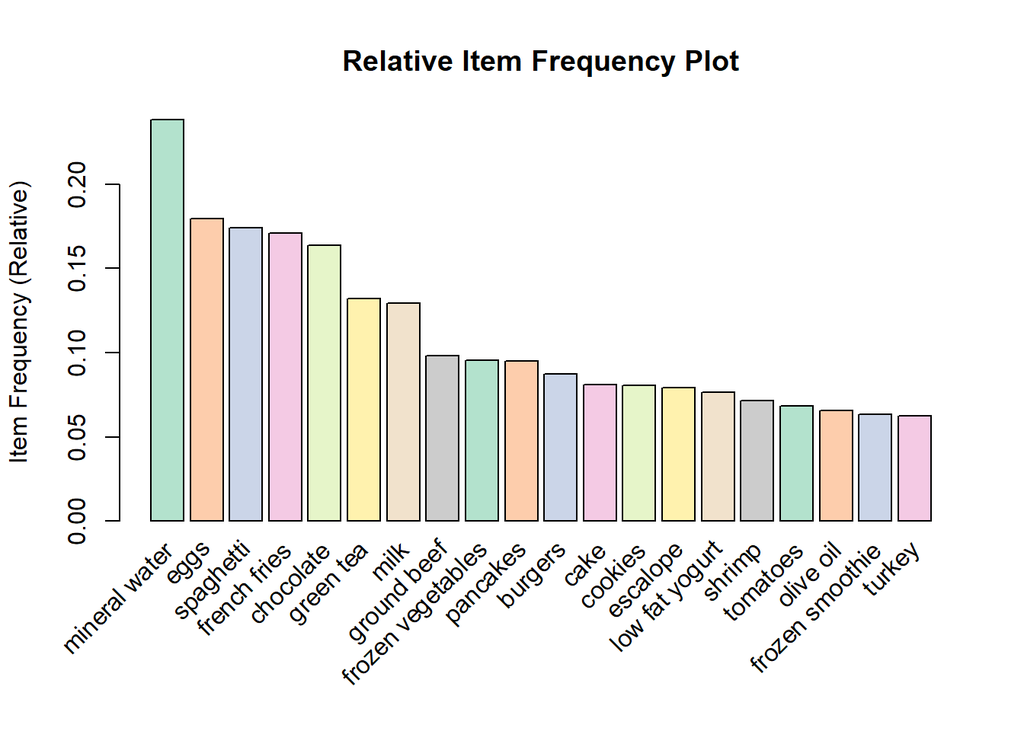

```r
#Displaying the 20 most items in the dataset
library(RColorBrewer)

arules::itemFrequencyPlot(sales.data,topN=20,col=brewer.pal(8,'Pastel2'),main='Relative Item Frequency Plot',type="relative",ylab="Item Frequency (Relative)")
```

In addition to the most frequent items that had been suggested by the summary, the graph also shows that green tea, milk, ground beef, frozen vegetables, pancakes, burgers, cakes, cookies, escalope, low fat yogurt, shrimp, tomatoes, olive oil, frozen smoothie and turkey appear more frequently in the transactions.

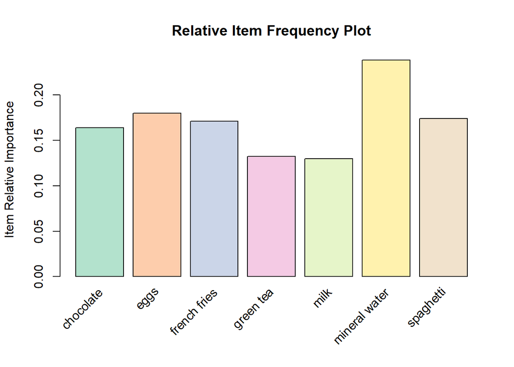

```r
# Displaying items whose relative importance is at least 10%

arules::itemFrequencyPlot(sales.data,support = 0.1,col=brewer.pal(8,'Pastel2'),main='Relative Item Frequency Plot',type="relative",ylab="Item Relative Importance")
```

Out of the top most frequent items, we have 7 items that hava at least 10% importance. These include; chocolate, eggs, french fries, green tea, milk, mineral water and spaghetti. With mineral water being the most relevant.

## 4.Building the Model

```r
# Building a model based on association rules
# using the apriori function
# ---
# We use Min Support as 0.001 and confidence as 0.8
#
rules <- apriori (sales.data, parameter = list(supp = 0.001, conf = 0.8))
```

```
## Apriori
##
## Parameter specification:
##  confidence minval smax arem  aval originalSupport maxtime support minlen
##         0.8    0.1    1 none FALSE            TRUE       5   0.001      1
##  maxlen target  ext
##      10  rules TRUE
##
## Algorithmic control:
##  filter tree heap memopt load sort verbose
##     0.1 TRUE TRUE  FALSE TRUE    2    TRUE
##
## Absolute minimum support count: 7
##
## set item appearances ...[0 item(s)] done [0.00s].
## set transactions ...[119 item(s), 7501 transaction(s)] done [0.00s].
## sorting and recoding items ... [116 item(s)] done [0.00s].
## creating transaction tree ... done [0.00s].
## checking subsets of size 1 2 3 4 5 6 done [0.01s].
## writing ... [74 rule(s)] done [0.00s].
## creating S4 object  ... done [0.00s].
```

```r
rules
```

```
## set of 74 rules
```

With a minimum support of 0.001 and minimum confidence of 0.8, we get a total of 74 rules.

```r
# Changing the minsupp and minconf parameters to observe the changes in the number of rules
# Building a apriori model with Min Support as 0.002 and confidence as 0.8.
rules2 <- apriori (sales.data,parameter = list(supp = 0.002, conf = 0.8))
```

```
## Apriori
##
## Parameter specification:
##  confidence minval smax arem  aval originalSupport maxtime support minlen
##         0.8    0.1    1 none FALSE            TRUE       5   0.002      1
##  maxlen target  ext
##      10  rules TRUE
##
## Algorithmic control:
##  filter tree heap memopt load sort verbose
##     0.1 TRUE TRUE  FALSE TRUE    2    TRUE
##
## Absolute minimum support count: 15
##
## set item appearances ...[0 item(s)] done [0.00s].
## set transactions ...[119 item(s), 7501 transaction(s)] done [0.00s].
## sorting and recoding items ... [115 item(s)] done [0.00s].
## creating transaction tree ... done [0.00s].
## checking subsets of size 1 2 3 4 5 done [0.00s].
## writing ... [2 rule(s)] done [0.00s].
## creating S4 object  ... done [0.00s].
```

```r
# Building apriori model with Min Support as 0.001 and confidence as 0.6.
rules3 <- apriori (sales.data, parameter = list(supp = 0.001, conf = 0.6))
```

```
## Apriori
##
## Parameter specification:
##  confidence minval smax arem  aval originalSupport maxtime support minlen
##         0.6    0.1    1 none FALSE            TRUE       5   0.001      1
##  maxlen target  ext
##      10  rules TRUE
##
## Algorithmic control:
##  filter tree heap memopt load sort verbose
##     0.1 TRUE TRUE  FALSE TRUE    2    TRUE
##
## Absolute minimum support count: 7
##
## set item appearances ...[0 item(s)] done [0.00s].
## set transactions ...[119 item(s), 7501 transaction(s)] done [0.00s].
## sorting and recoding items ... [116 item(s)] done [0.00s].
## creating transaction tree ... done [0.00s].
## checking subsets of size 1 2 3 4 5 6 done [0.01s].
## writing ... [545 rule(s)] done [0.00s].
## creating S4 object  ... done [0.00s].
```

```r
rules2
```

```
## set of 2 rules
```

```r
rules3
```

```
## set of 545 rules
```

```r
#building an appriori model with as minsup 0.001 and minconf as 0.7
rules4 <-apriori (sales.data, parameter = list(supp = 0.001, conf = 0.7))
```

```
## Apriori
##
## Parameter specification:
##  confidence minval smax arem  aval originalSupport maxtime support minlen
##         0.7    0.1    1 none FALSE            TRUE       5   0.001      1
##  maxlen target  ext
##      10  rules TRUE
##
## Algorithmic control:
##  filter tree heap memopt load sort verbose
##     0.1 TRUE TRUE  FALSE TRUE    2    TRUE
##
## Absolute minimum support count: 7
##
## set item appearances ...[0 item(s)] done [0.00s].
## set transactions ...[119 item(s), 7501 transaction(s)] done [0.01s].
## sorting and recoding items ... [116 item(s)] done [0.00s].
## creating transaction tree ... done [0.00s].
## checking subsets of size 1 2 3 4 5 6 done [0.01s].
## writing ... [200 rule(s)] done [0.00s].
## creating S4 object  ... done [0.00s].
```

```r
rules4
```

```
## set of 200 rules
```

The set of parameters return a total of 200 rules which is a good number to work with

```r
#printing the summary of the created rules
summary(rules4)
```

```
## set of 200 rules
##
## rule length distribution (lhs + rhs):sizes
##   3   4   5   6
##  44 122  33   1
##
##    Min. 1st Qu.  Median    Mean 3rd Qu.    Max.
##   3.000   4.000   4.000   3.955   4.000   6.000
##
## summary of quality measures:
##     support           confidence        coverage             lift
##  Min.   :0.001067   Min.   :0.7000   Min.   :0.001067   Min.   : 2.937
##  1st Qu.:0.001067   1st Qu.:0.7273   1st Qu.:0.001466   1st Qu.: 3.088
##  Median :0.001200   Median :0.7500   Median :0.001466   Median : 3.616
##  Mean   :0.001330   Mean   :0.7767   Mean   :0.001728   Mean   : 4.160
##  3rd Qu.:0.001466   3rd Qu.:0.8139   3rd Qu.:0.001866   3rd Qu.: 4.418
##  Max.   :0.003066   Max.   :1.0000   Max.   :0.004133   Max.   :12.722
##      count
##  Min.   : 8.00
##  1st Qu.: 8.00
##  Median : 9.00
##  Mean   : 9.98
##  3rd Qu.:11.00
##  Max.   :23.00
##
## mining info:
##        data ntransactions support confidence
##  sales.data          7501   0.001        0.7
```

```r
#displaying the first five itemsets with the highest lift from the rules
inspect(head(rules4, n = 5, by ="lift"))
```

```
##     lhs                                          rhs        support
## [1] {eggs,mineral water,pasta}                => {shrimp}   0.001333156
## [2] {french fries,mushroom cream sauce,pasta} => {escalope} 0.001066524
## [3] {milk,pasta}                              => {shrimp}   0.001599787
## [4] {mushroom cream sauce,pasta}              => {escalope} 0.002532996
## [5] {mineral water,pasta}                     => {shrimp}   0.001599787
##     confidence coverage    lift     count
## [1] 0.9090909  0.001466471 12.72218 10
## [2] 1.0000000  0.001066524 12.60672  8
## [3] 0.8571429  0.001866418 11.99520 12
## [4] 0.9500000  0.002666311 11.97639 19
## [5] 0.7500000  0.002133049 10.49580 12
```

The first rule implies that people who purchase eggs, mineral water and pasta have a 90% chance of purchasing shrimp as well. From the second transaction, people who purchase french fries, mushroom cream sause and pasta have 100% chance to purchase escalope.

```r
#creating a html file displaying all the available rules
p <- inspectDT(rules4)
htmlwidgets::saveWidget(p, "arules.html", selfcontained = TRUE)
browseURL("arules.html")
```

## 5.Visualizations

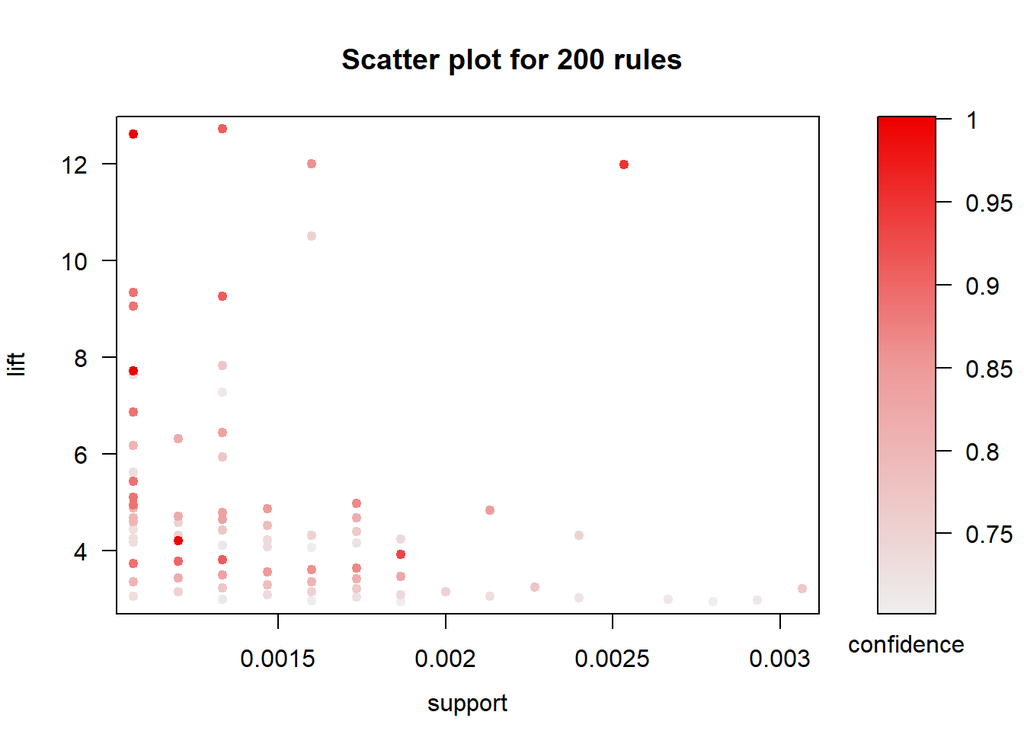

```r
#scatter plot with support on the x-axis and lift on the y-axis
#the intensity of the items shows the confidence of that rule
plot(rules4, measure = c("support", "lift"), shading = "confidence", jitter = 0)
```

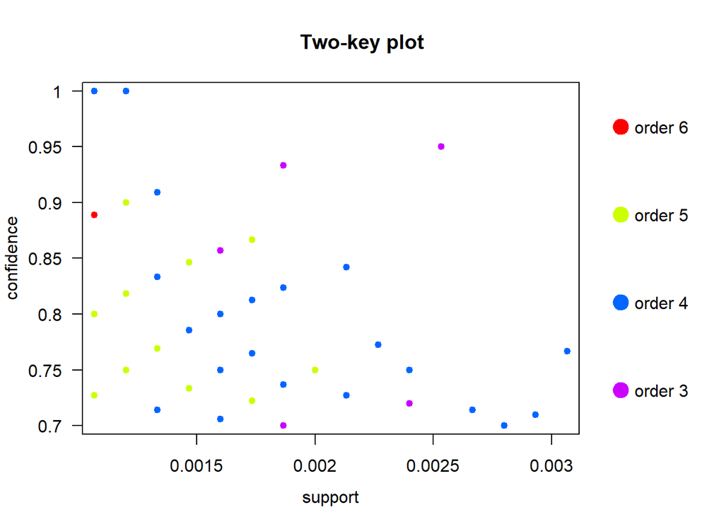

```r
# plotting a two key plot with support on the x-axis and confidence on the y-axis
# the color of the points is used to indicate “order,” i.e the number of items contained in the rule.
plot(rules4, method = "two-key plot", jitter = 0)
```

From the plot above, we can see that most of the rules contained 4 items while just one observation contains 6 items

```r
#building an interactive plot
#arulesViz::plotly_arules(rules4)
```

[output not shown]

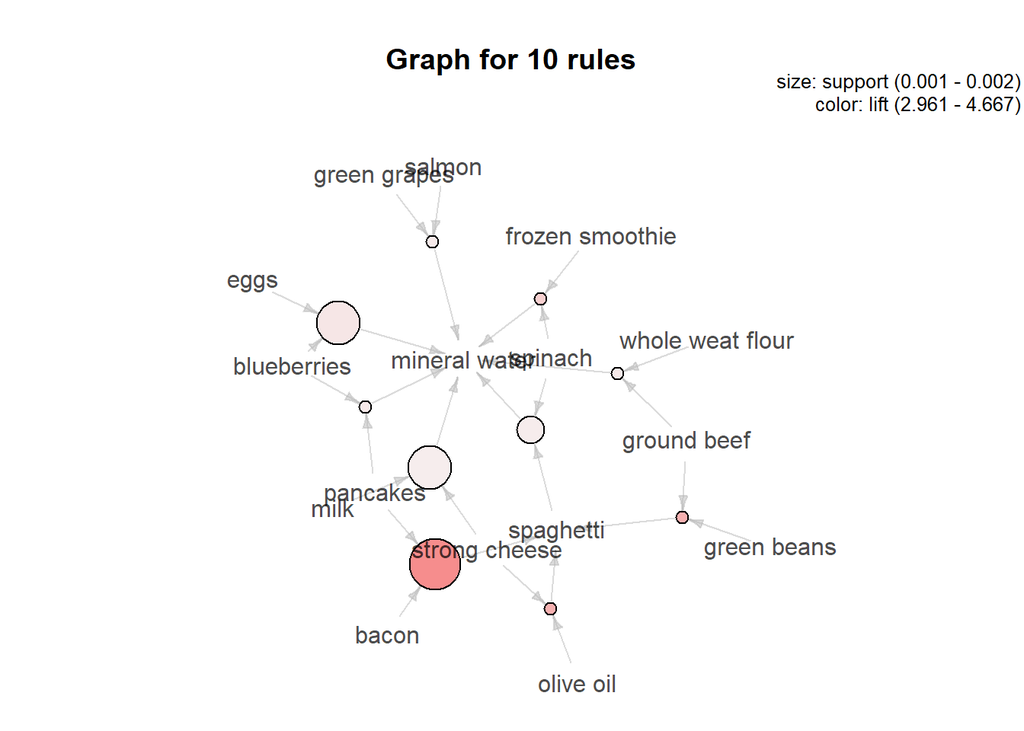

```r
#graphical representation of the first 10 rules
plot(rules4[1:10],

method = "graph",

control = list(type = "items"))
```

From the graph above, we observe that most items are consolidated around mineral water. We also observe that people who purchase pancake and bacon have high chances of purchasing spaghetti.

[output not shown]

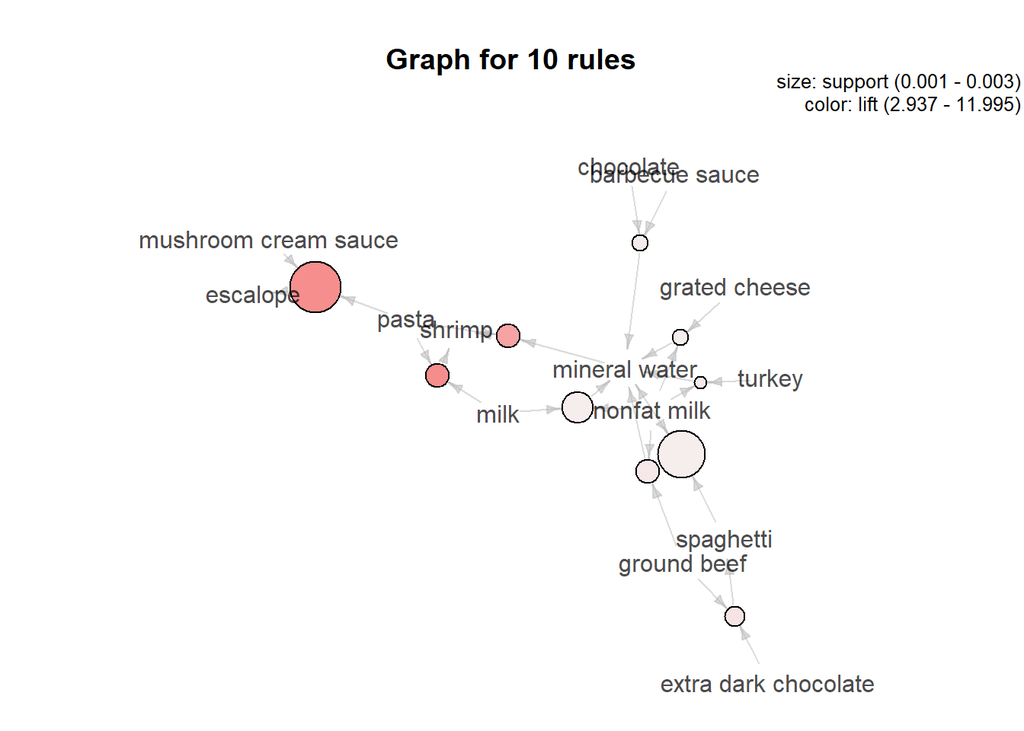

```r
#graphical representation of the first 5 rules
plot(rules4[11:20],

method = "graph",

control = list(type = "items"))
```

We also observe that most points are consolidated around mineral water.

strong relationships observed are: * purchase of mushroom cream sauce and pasta could mean purchase of escalope * purchase of pasta and milk could contribute to purchase of shrimp * purchase of mineral water could contribute to purchase of shrimp

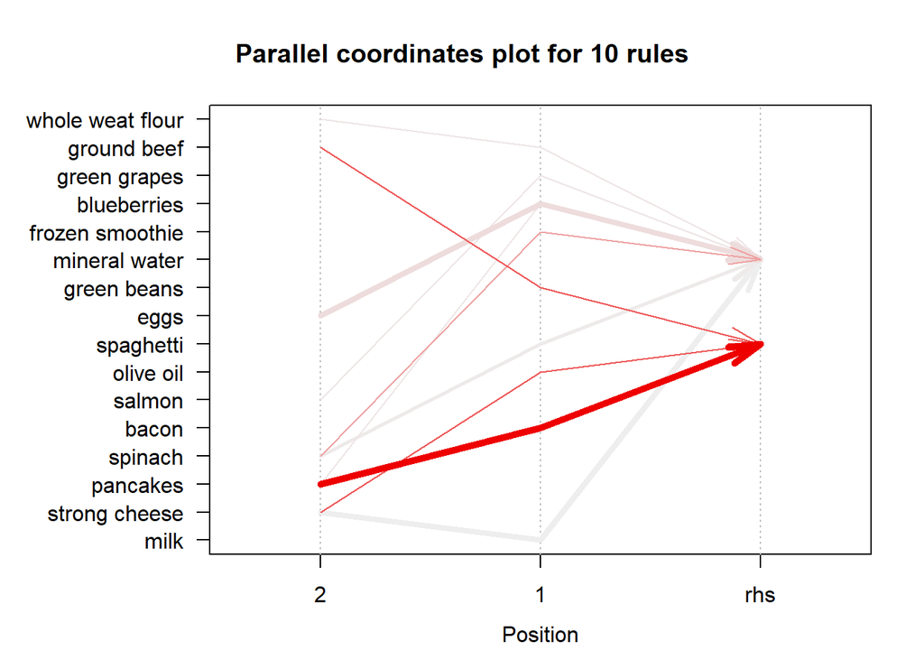

```r
#A graph of individual rule representation of the first 10 rules.

plot(rules4[1:10],

method = "paracoord",

control = list(reorder = TRUE))
```

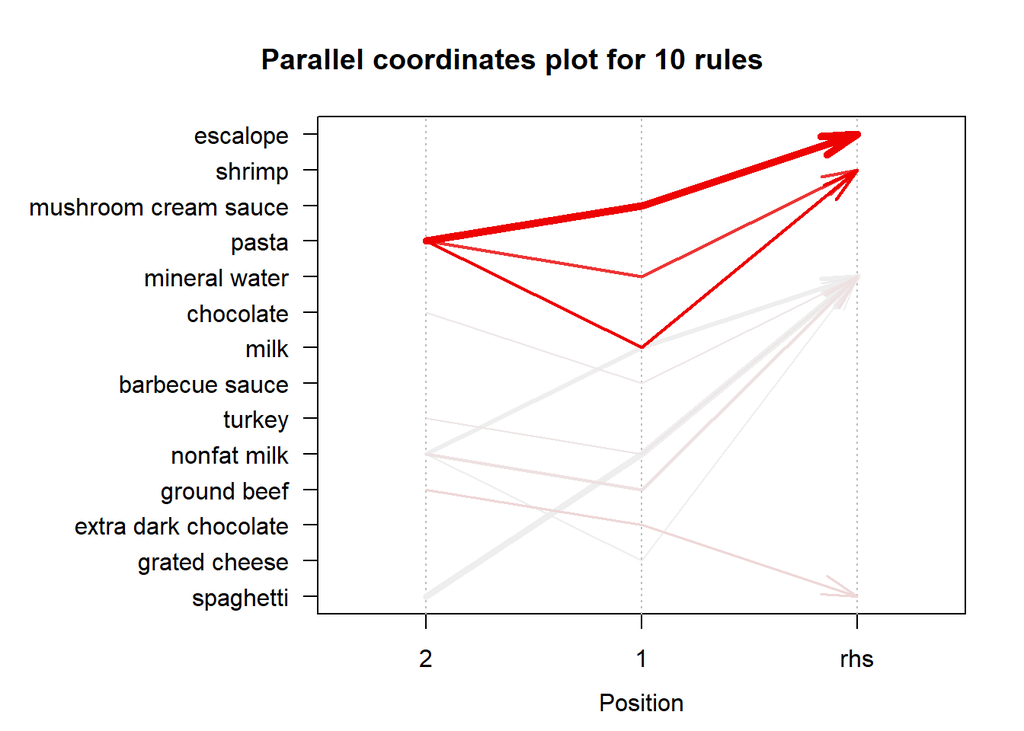

```r
#A graph of individual rule representation of the first 10 rules.

plot(rules4[11:20],

method = "paracoord",

control = list(reorder = TRUE))
```

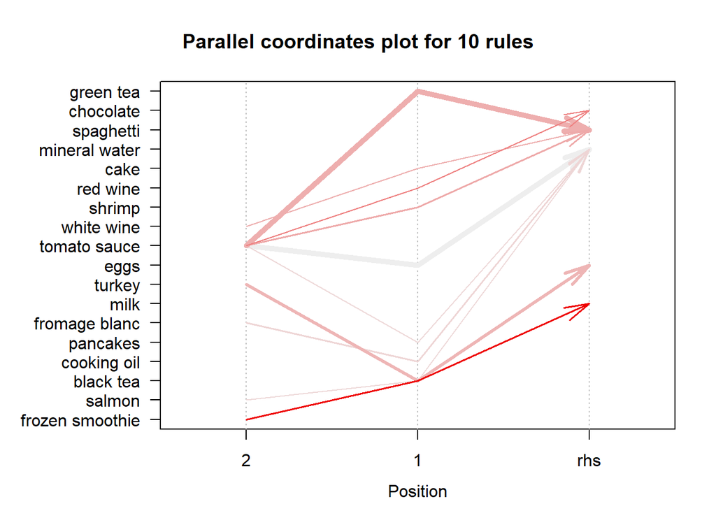

```r
#A graph of individual rule representation of the first 10 rules.

plot(rules4[21:30],

method = "paracoord",

control = list(reorder = TRUE))
```

## 6.Sorting

```r
# Ordering these rules by a criteria such as the level of confidence
# then looking at the first ten rules.

rules4<-sort(rules4, by="confidence", decreasing=TRUE)
inspect(rules4[1:10])
```

```
##      lhs                       rhs                 support confidence    coverage      lift count
## [1]  {french fries,
##       mushroom cream sauce,
##       pasta}                => {escalope}      0.001066524  1.0000000 0.001066524 12.606723     8
## [2]  {ground beef,
##       light cream,
##       olive oil}            => {mineral water} 0.001199840  1.0000000 0.001199840  4.195190     9
## [3]  {cake,
##       meatballs,
##       mineral water}        => {milk}          0.001066524  1.0000000 0.001066524  7.717078     8
## [4]  {cake,
##       olive oil,
##       shrimp}               => {mineral water} 0.001199840  1.0000000 0.001199840  4.195190     9
## [5]  {mushroom cream sauce,
##       pasta}                => {escalope}      0.002532996  0.9500000 0.002666311 11.976387    19
## [6]  {red wine,
##       soup}                 => {mineral water} 0.001866418  0.9333333 0.001999733  3.915511    14
## [7]  {eggs,
##       mineral water,
##       pasta}                => {shrimp}        0.001333156  0.9090909 0.001466471 12.722185    10
## [8]  {herb & pepper,
##       mineral water,
##       rice}                 => {ground beef}   0.001333156  0.9090909 0.001466471  9.252498    10
## [9]  {ground beef,
##       pancakes,
##       whole wheat rice}     => {mineral water} 0.001333156  0.9090909 0.001466471  3.813809    10
## [10] {frozen vegetables,
##       milk,
##       spaghetti,
##       turkey}               => {mineral water} 0.001199840  0.9000000 0.001333156  3.775671     9
```

```r
# Ordering these rules by lift
# then looking at the first ten rules.

rules4<-sort(rules4, by="lift", decreasing=TRUE)
inspect(rules4[1:10])
```

```
##      lhs                       rhs                     support confidence    coverage      lift count
## [1]  {eggs,
##       mineral water,
##       pasta}                => {shrimp}            0.001333156  0.9090909 0.001466471 12.722185    10
## [2]  {french fries,
##       mushroom cream sauce,
##       pasta}                => {escalope}          0.001066524  1.0000000 0.001066524 12.606723     8
## [3]  {milk,
##       pasta}                => {shrimp}            0.001599787  0.8571429 0.001866418 11.995203    12
## [4]  {mushroom cream sauce,
##       pasta}                => {escalope}          0.002532996  0.9500000 0.002666311 11.976387    19
## [5]  {mineral water,
##       pasta}                => {shrimp}            0.001599787  0.7500000 0.002133049 10.495802    12
## [6]  {chocolate,
##       ground beef,
##       milk,
##       mineral water,
##       spaghetti}            => {frozen vegetables} 0.001066524  0.8888889 0.001199840  9.325253     8
## [7]  {herb & pepper,
##       mineral water,
##       rice}                 => {ground beef}       0.001333156  0.9090909 0.001466471  9.252498    10
## [8]  {grated cheese,
##       mineral water,
##       rice}                 => {ground beef}       0.001066524  0.8888889 0.001199840  9.046887     8
## [9]  {burgers,
##       herb & pepper,
##       spaghetti}            => {ground beef}       0.001333156  0.7692308 0.001733102  7.829037    10
## [10] {cake,
##       meatballs,
##       mineral water}        => {milk}              0.001066524  1.0000000 0.001066524  7.717078     8
```

From the above, items with the rules with the highest lift point to purchase of shrimp and escalope. This means that all these items are positively correlated.

```r
# Ordering these rules by lift in ascending order
# then looking at the first ten rules.

rules4<-sort(rules4, by="lift", decreasing=FALSE)
inspect(rules4[1:10])
```

```
##      lhs                    rhs                 support confidence    coverage     lift count
## [1]  {milk,
##       nonfat milk}       => {mineral water} 0.001866418  0.7000000 0.002666311 2.936633    14
## [2]  {eggs,
##       tomato sauce}      => {mineral water} 0.001866418  0.7000000 0.002666311 2.936633    14
## [3]  {chocolate,
##       frozen vegetables,
##       olive oil}         => {mineral water} 0.002799627  0.7000000 0.003999467 2.936633    21
## [4]  {milk,
##       strong cheese}     => {mineral water} 0.001599787  0.7058824 0.002266364 2.961311    12
## [5]  {cooking oil,
##       whole wheat pasta} => {mineral water} 0.001599787  0.7058824 0.002266364 2.961311    12
## [6]  {milk,
##       shrimp,
##       soup}              => {mineral water} 0.001599787  0.7058824 0.002266364 2.961311    12
## [7]  {chocolate,
##       olive oil,
##       tomatoes}          => {mineral water} 0.001599787  0.7058824 0.002266364 2.961311    12
## [8]  {cooking oil,
##       eggs,
##       spaghetti}         => {mineral water} 0.002932942  0.7096774 0.004132782 2.977232    22
## [9]  {spaghetti,
##       spinach}           => {mineral water} 0.001333156  0.7142857 0.001866418 2.996564    10
## [10] {grated cheese,
##       nonfat milk}       => {mineral water} 0.001333156  0.7142857 0.001866418 2.996564    10
```

By setting rules to ascendig order by lift, we observe that the lowest value of the lift is greater than 1 hence conclude that all the items are positively correlated. We also observe that all these rules have also been ordered by confidence in ascending order. Hence lift and confidence are also positively correlated

```r
# say we are interested in making a promotion to enhance the sale of milk hence,
# create a subset of rules concerning these products

milk <- subset(rules, subset = rhs %pin% "milk")

# Then order by confidence
milk <-sort(milk, by="confidence", decreasing=TRUE)
inspect(milk[1:5])
```

```
##     lhs                                  rhs    support     confidence
## [1] {cake,meatballs,mineral water}    => {milk} 0.001066524 1.0000000
## [2] {escalope,hot dogs,mineral water} => {milk} 0.001066524 0.8888889
## [3] {meatballs,whole wheat pasta}     => {milk} 0.001333156 0.8333333
## [4] {black tea,frozen smoothie}       => {milk} 0.001199840 0.8181818
## [5] {burgers,ground beef,olive oil}   => {milk} 0.001066524 0.8000000
##     coverage    lift     count
## [1] 0.001066524 7.717078  8
## [2] 0.001199840 6.859625  8
## [3] 0.001599787 6.430898 10
## [4] 0.001466471 6.313973  9
## [5] 0.001333156 6.173663  8
```

To enhance sale of milk we propose that: * mineral water and milk be placed together * cake, hot dogs and burgers should be placed together * meatballs and ground beef should be placed together

```r
# What if we wanted to determine items that customers might buy
# who have previously bought yogurt?
# ---
#
# Subset the rules
milk <- subset(rules, subset = lhs %pin% "milk")

# Order by confidence
milk <-sort(milk, by="confidence", decreasing=TRUE)

# inspect top 5
inspect(milk[1:5])
```

```
##     lhs                    rhs                     support confidence    coverage     lift count
## [1] {frozen vegetables,
##      milk,
##      spaghetti,
##      turkey}            => {mineral water}     0.001199840  0.9000000 0.001333156 3.775671     9
## [2] {cake,
##      meatballs,
##      milk}              => {mineral water}     0.001066524  0.8888889 0.001199840 3.729058     8
## [3] {burgers,
##      milk,
##      salmon}            => {spaghetti}         0.001066524  0.8888889 0.001199840 5.105326     8
## [4] {chocolate,
##      ground beef,
##      milk,
##      mineral water,
##      spaghetti}         => {frozen vegetables} 0.001066524  0.8888889 0.001199840 9.325253     8
## [5] {ground beef,
##      nonfat milk}       => {mineral water}     0.001599787  0.8571429 0.001866418 3.595877    12
```

** Recommendations**

The following recommendations will be proposed to the marketing team:

- To enhance sale of milk the following aisles should be close to each other:*
- Meat aisle - meatballs, ground beef
- Snack aisle - cake, hot dogs, burgers
- Drinks aisle - mineral water and milk